# 01 Read OS Open Greenspace

A recommended approach to geospatial exploratory data analysis given a new geospatial dataset.

## GeoPackage

The [GeoPackage](https://www.geopackage.org/) (GPKG) is an open geospatial data format enabling the storage of geospatial data within a SQLite database. The [SQLite database](https://www.sqlite.org/index.html) provides a lightweight and portable database storage solution. Each dataset is stored a feature table within the database and can be queried directly using SQL or via spatial applications including the `R` geospatial vector package [`sf`](https://r-spatial.github.io/sf/index.html).

## `sf`

[`sf`](https://r-spatial.github.io/sf/index.html) extends the `data.frame` or `tibble` objects with a list column containing simple feature geometries to allow spatial operations. Geometric operations are performed by GEOS and S2 for geometric operations, GDAL for file access and PROJ for coordinate reference system operations.

## OS Open Greenspace

The OS OpenData product [OS Open Greenspace](https://www.ordnancesurvey.co.uk/business-government/products/open-map-greenspace) depicts the location and extent of spaces such as parks and sports facilities that are likely to be accessible to the public. Where appropriate, it also includes Access Points to show how people get into these sites. Its primary purpose is to enable members of the public to find and access greenspaces near them for exercise and recreation.

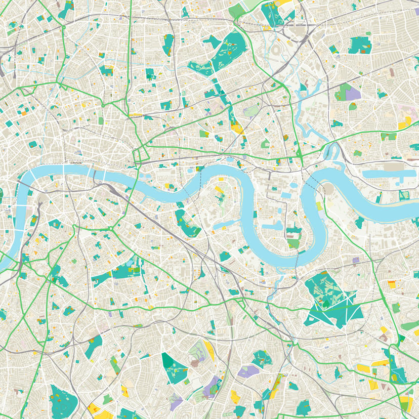

Example of OS Open Greenspace

```r
library(sf)
```

## Create an `sf` object from GeoPackage (GPKG)

```r
# Create an sf data.frame object from the Greenspace file
gdf <- st_read('../../data/ordnance-survey/os-open-greenspace-gb.gpkg',
               layer = 'greenspace_site')
```

## Return top *n* rows

```r
head(gdf, n = 10)
```

```
Simple feature collection with 10 features and 6 fields
Geometry type: MULTIPOLYGON
Dimension:     XY
Bounding box:  xmin: 125698 ymin: 640034.6 xmax: 384271.1 ymax: 882383.9
Projected CRS: OSGB 1936 / British National Grid
                                     id             function.                   distinctive_name_1
1  F34085A3-E9BA-7DA2-E053-AAEFA00AB6EA     Religious Grounds                          Monzie Kirk
2  F34085C6-4B7A-7DA2-E053-AAEFA00AB6EA Other Sports Facility                                 <NA>
3  F34085DA-3EE1-7DA2-E053-AAEFA00AB6EA     Religious Grounds Gardenstown Free Presbyterian Church
4  F340858A-BBEB-7DA2-E053-AAEFA00AB6EA         Playing Field                          Mcleod Park
5  F3408710-F3BB-7DA2-E053-AAEFA00AB6EA            Play Space                                 <NA>
6  F340859B-5160-7DA2-E053-AAEFA00AB6EA            Play Space                                 <NA>
7  F3408632-C7BF-7DA2-E053-AAEFA00AB6EA     Religious Grounds   St Kiarans Kilchoman Parish Church
8  F340858D-E8C0-7DA2-E053-AAEFA00AB6EA            Play Space                                 <NA>
9  F340858A-07F2-7DA2-E053-AAEFA00AB6EA            Play Space                                 <NA>
10 F34085DB-4FD0-7DA2-E053-AAEFA00AB6EA            Play Space                                 <NA>
   distinctive_name_2 distinctive_name_3 distinctive_name_4                       geometry
1                <NA>               <NA>               <NA> MULTIPOLYGON (((287885.1 72...
2                <NA>               <NA>               <NA> MULTIPOLYGON (((361498.8 74...
3                <NA>               <NA>               <NA> MULTIPOLYGON (((379609.8 86...
4                <NA>               <NA>               <NA> MULTIPOLYGON (((349314.7 86...
5                <NA>               <NA>               <NA> MULTIPOLYGON (((278437.3 88...
6                <NA>               <NA>               <NA> MULTIPOLYGON (((384260.1 64...
7                <NA>               <NA>               <NA> MULTIPOLYGON (((125762.1 65...
8                <NA>               <NA>               <NA> MULTIPOLYGON (((211788.9 77...
9                <NA>               <NA>               <NA> MULTIPOLYGON (((380103.4 77...
10               <NA>               <NA>               <NA> MULTIPOLYGON (((353076.3 83...
```

## Return columns

```r
# Return data.frame columns
names(gdf)
```

```
[1] "id"                 "function."          "distinctive_name_1" "distinctive_name_2"
[5] "distinctive_name_3" "distinctive_name_4" "geometry"
```

## Count rows

```r
nrow(gdf)
```

```
[1] 150149
```

```r
# Alternatively, get the dimensions of the object and take the first (rows)
dim(gdf)[1]
```

```
[1] 150149
```

## Check Coordinate Reference System (CRS) assignment

```r
st_crs(gdf)
```

```
Coordinate Reference System:
  User input: OSGB 1936 / British National Grid
  wkt:
PROJCRS["OSGB 1936 / British National Grid",
    BASEGEOGCRS["OSGB 1936",
        DATUM["OSGB 1936",
            ELLIPSOID["Airy 1830",6377563.396,299.3249646,
                LENGTHUNIT["metre",1]]],
        PRIMEM["Greenwich",0,
            ANGLEUNIT["degree",0.0174532925199433]],
        ID["EPSG",4277]],
    CONVERSION["British National Grid",
        METHOD["Transverse Mercator",
            ID["EPSG",9807]],
        PARAMETER["Latitude of natural origin",49,
            ANGLEUNIT["degree",0.0174532925199433],
            ID["EPSG",8801]],
        PARAMETER["Longitude of natural origin",-2,
            ANGLEUNIT["degree",0.0174532925199433],
            ID["EPSG",8802]],
        PARAMETER["Scale factor at natural origin",0.9996012717,
            SCALEUNIT["unity",1],
            ID["EPSG",8805]],
        PARAMETER["False easting",400000,
            LENGTHUNIT["metre",1],
            ID["EPSG",8806]],
        PARAMETER["False northing",-100000,
            LENGTHUNIT["metre",1],
            ID["EPSG",8807]]],
    CS[Cartesian,2],
        AXIS["(E)",east,
            ORDER[1],
            LENGTHUNIT["metre",1]],
        AXIS["(N)",north,
            ORDER[2],
            LENGTHUNIT["metre",1]],
    USAGE[
        SCOPE["unknown"],
        AREA["UK - Britain and UKCS 49°46'N to 61°01'N, 7°33'W to 3°33'E"],
        BBOX[49.75,-9.2,61.14,2.88]],
    ID["EPSG",27700]]
```

## Count rows by geometry type

```r
table(st_geometry_type(gdf))
```

```
          GEOMETRY              POINT         LINESTRING            POLYGON         MULTIPOINT
                 0                  0                  0                  0                  0
   MULTILINESTRING       MULTIPOLYGON GEOMETRYCOLLECTION     CIRCULARSTRING      COMPOUNDCURVE
                 0             150149                  0                  0                  0
      CURVEPOLYGON         MULTICURVE       MULTISURFACE              CURVE            SURFACE
                 0                  0                  0                  0                  0
 POLYHEDRALSURFACE                TIN           TRIANGLE
                 0                  0                  0
```

## Check geometry validity

```r
table(st_is_valid(gdf))
```

```
  TRUE
150149
```